# lab2

Lab2 Yu Wu

```python
import matplotlib
import matplotlib.pyplot as plt
import numpy as np
import pandas as pd
from scipy import stats, signal
matplotlib.rc('figure', figsize=(9, 5))
```

Problem 1

1.A X = 5.4; Y = 7.3

```python
cosmic_rays = 5.4
gamma_rays = 7.3
```

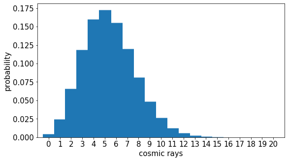

```python
dist = stats.poisson(cosmic_rays)
x = np.arange(0, 21)
pmf = dist.pmf(x)
plt.xlabel("cosmic rays")
plt.ylabel("probability")
plt.vlines(x, 0, pmf, linewidth=25, color="C0")
plt.xticks(x)
plt.ylim(0, None);
```

1.B

```python
def plot_sum(pmf, n, *args, **kwargs):
    new_pmf = pmf
    for i in range(n):
        new_pmf = np.convolve(new_pmf, pmf)
    plt.vlines(range(len(new_pmf)), 0, new_pmf, *args, **kwargs)
    plt.xlim(0, None)
    plt.ylim(0, None)
```

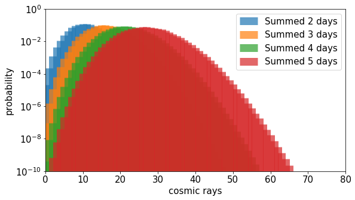

```python
for i in range(1, 5):
    plot_sum(dist.pmf(x), i, linewidth=13, color=f"C{i - 1}", alpha=0.7)
plt.xlabel("cosmic rays")
plt.ylabel("probability")
plt.legend([f"Summed {i + 1} days" for i in range(1, 5)])
plt.yscale('log')
plt.xlim(0, 80)
plt.ylim(1e-10, 1);
```

The summed probability distribution is still a Poisson distribution.

1.C

```python
def plot_average(pmf, n, *args, **kwargs):
    new_pmf = pmf
    for i in range(n):
        new_pmf = np.convolve(new_pmf, pmf)
    plt.vlines(np.arange(len(new_pmf)) / (n + 1), 0, new_pmf, *args, **kwargs)
    plt.xlim(0, None)
    plt.ylim(0, None)
```

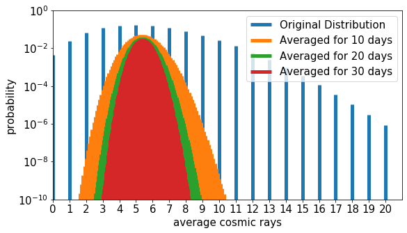

```python
days = [0, 10, 20, 30]
for i in days:
    plot_average(pmf, i, linewidth=5, color=f"C{i // 10}")
plt.xlabel("average cosmic rays")
plt.ylabel("probability")
plt.legend(['Original Distribution', *[f"Averaged for {n} days" for n in days[1:]]])
plt.yscale('log')
plt.xticks(range(0, 21))
plt.xlim(0, 21)
plt.ylim(1e-10, 1);
```

The more observing cosmic rays, the probability masses are more to the center.

```python
N = 5
print(cosmic_rays * N)
print(gamma_rays * N)
```

```
27.0
36.5
```

```python
prob = 1 - stats.poisson.cdf(k = gamma_rays * N, mu = cosmic_rays * N, loc=0)
print(prob)
```

```
0.038798267642610296
```

```python
sigV = stats.norm.ppf(1-prob)
print(sigV)
```

```
1.7648050521244978
```

The observation point is at about 1.76 σ away from mean.

Problem 2

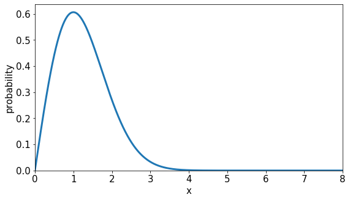

```python
scale = 1
dist = stats.rayleigh(scale=scale)
x = np.linspace(0, 8, 1000)
plt.xlabel("x")
plt.ylabel("probability")
plt.plot(x, dist.pdf(x), linewidth=3)
plt.xlim(0, 8)
plt.xticks(range(0, 9))
plt.ylim(0, None);
```

```python
def plot_average_rayleigh(x, pdf, n, *args, **kwargs):
    new_pdf = pdf
    for i in range(n):
        new_pdf = np.convolve(new_pdf, pdf)
    plt.plot(np.linspace(x[0], x[-1], len(new_pdf)), new_pdf, *args, **kwargs)
    plt.xlim(x[0], x[-1])
```

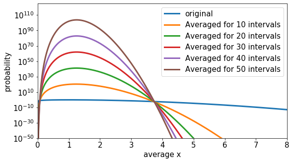

```python
pdf = dist.pdf(x)
nums = [0, 10, 20, 30, 40, 50]
for i in nums:
    plot_average_rayleigh(x, pdf, i, linewidth=3)
plt.xlabel("average x")
plt.ylabel("probability")
plt.yscale('log')
plt.ylim(1e-50, None);
plt.legend(['original', *[f"Averaged for {n} intervals" for n in nums[1:]]]);
```

The shapes of the distributions get taller and narrower, they don't look Gaussian yet.

My computer can't plot with n > 200, it will show a empty graph. But I think it will become to the same as Gaussian.

Problem 3 Version 1

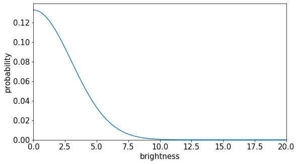

```python
dist = stats.norm(scale=3)
x = np.linspace(0, 20, 1000)
plt.plot(x, dist.pdf(x))
plt.xlim(0, 20)
plt.ylim(0, None);
plt.xlabel("brightness")
plt.ylabel("probability")
```

I choose the strength of signal is 17.

```python
prob = dist.sf(17)
print(prob)
```

```
7.280110073914057e-09
```

```python
stats.norm.ppf(1 - prob)
```

```
5.666666666750822
```

This result is greater than 5σ, so we can claim the discovery.

Version 2

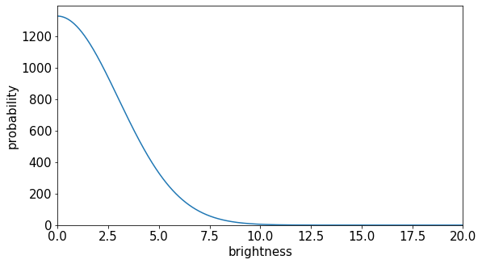

```python
dist = stats.norm(scale=3)
x = np.linspace(0, 20, 1000)
plt.plot(x, 10_000 * dist.pdf(x))
plt.xlim(0, 20)
plt.ylim(0, None);
plt.xlabel("brightness")
plt.ylabel("probability")
```

```python
prob = 10000 * dist.sf(17)
print(prob)
```

```
7.280110073914058e-05
```

```python
stats.norm.ppf(1 - prob)
```

```
3.798452710609889
```

This result is smaller than 5σ, so we can't claim the discovery.

Problem 4

4.A

```python
prob = stats.norm.sf(5)
thres_1 = dist.ppf(1 - prob)
print(thres_1)
```

```
14.999999999910528
```

The signal required for a 5-sigma detection in Version 1 is about 15.

4.B

```python
new_prob = prob / 10_000
thres_2 = dist.ppf(1 - new_prob)
print(thres_2)
```

```
19.651612460674965
```

The signal required for a 5-sigma detection in Version 2 is about 19.65.

4.C

```python
print(thres_2 / thres_1)
```

```
1.3101074973861455
```

About 31% brighter.

```python
# Factors of 10,000 cancel here
dist.sf(thres_2) / dist.sf(thres_1)
```

```
0.00010000008423938025
```

```python
n = 10e6 # trials factor of 10,000,000
new_prob = prob / n
thres_3 = dist.ppf(1 - new_prob)
print(thres_3)
```

```
22.542411418261633
```

```python
print(thres_3 / thres_1)
```

```
1.5028274278930729
```

4.D

[figure not shown]

```python
n = np.linspace(1e4, 1e8)
new_probs = prob / n
thresholds = dist.ppf(1 - new_probs)
plt.semilogx(n, thresholds)
plt.xlabel('trials factor')
plt.ylabel('signal threshold');
```

The signal threshold increases as the trials factor increases.

Extra credit

```python
factors = [1e4,1e5,1e6,1e7,1e8]
x=[]
prob = stats.rayleigh.sf(x=5)
for i,f in enumerate(factors):
    x.append(stats.norm.ppf(q=1-prob/f,loc=0,scale=X))
pd.DataFrame({'trial factor':factors,'5σ threshold':np.round(x,decimals=2)})
```

|  | trial factor | 5σ threshold |
| --- | --- | --- |
| 0 | 10000.0 | 33.24 |
| 1 | 100000.0 | 35.16 |
| 2 | 1000000.0 | 36.98 |
| 3 | 10000000.0 | 38.72 |
| 4 | 100000000.0 | 40.39 |

The increase rate is almost the same.